# Risk Factor Analysis

## Outcome Variable

**Outcome Variable:** ever_sstunted

## Predictor Variables

**Intervention Variable:** mwtkg

**Adjustment Set:**

- arm
- W_mage
- meducyrs
- feducyrs
- hhwealth_quart
- W_nchldlt5
- brthmon
- W_parity
- delta_W_mage
- delta_meducyrs
- delta_feducyrs
- delta_hhwealth_quart
- delta_W_nchldlt5
- delta_brthmon
- delta_W_parity

## Stratifying Variables

The analysis was stratified on these variable(s):

- agecat
- studyid
- country

## Data Summary

| agecat | studyid | country | mwtkg | ever_sstunted | n_cell | n |
| --- | --- | --- | --- | --- | --- | --- |
| 0-24 months | iLiNS-Zinc | BURKINA FASO | >=58 kg | 0 | 871 | 3216 |
| 0-24 months | iLiNS-Zinc | BURKINA FASO | >=58 kg | 1 | 66 | 3216 |
| 0-24 months | iLiNS-Zinc | BURKINA FASO | <52 kg | 0 | 1032 | 3216 |
| 0-24 months | iLiNS-Zinc | BURKINA FASO | <52 kg | 1 | 169 | 3216 |
| 0-24 months | iLiNS-Zinc | BURKINA FASO | [52-58) kg | 0 | 975 | 3216 |
| 0-24 months | iLiNS-Zinc | BURKINA FASO | [52-58) kg | 1 | 103 | 3216 |
| 0-24 months | JiVitA-3 | BANGLADESH | >=58 kg | 0 | 575 | 27196 |
| 0-24 months | JiVitA-3 | BANGLADESH | >=58 kg | 1 | 94 | 27196 |
| 0-24 months | JiVitA-3 | BANGLADESH | <52 kg | 0 | 20106 | 27196 |
| 0-24 months | JiVitA-3 | BANGLADESH | <52 kg | 1 | 4647 | 27196 |
| 0-24 months | JiVitA-3 | BANGLADESH | [52-58) kg | 0 | 1498 | 27196 |
| 0-24 months | JiVitA-3 | BANGLADESH | [52-58) kg | 1 | 276 | 27196 |
| 0-24 months | LCNI-5 | MALAWI | >=58 kg | 0 | 102 | 838 |
| 0-24 months | LCNI-5 | MALAWI | >=58 kg | 1 | 12 | 838 |
| 0-24 months | LCNI-5 | MALAWI | <52 kg | 0 | 370 | 838 |
| 0-24 months | LCNI-5 | MALAWI | <52 kg | 1 | 134 | 838 |
| 0-24 months | LCNI-5 | MALAWI | [52-58) kg | 0 | 189 | 838 |
| 0-24 months | LCNI-5 | MALAWI | [52-58) kg | 1 | 31 | 838 |
| 0-24 months | MAL-ED | BANGLADESH | >=58 kg | 0 | 45 | 254 |
| 0-24 months | MAL-ED | BANGLADESH | >=58 kg | 1 | 3 | 254 |
| 0-24 months | MAL-ED | BANGLADESH | <52 kg | 0 | 113 | 254 |
| 0-24 months | MAL-ED | BANGLADESH | <52 kg | 1 | 49 | 254 |
| 0-24 months | MAL-ED | BANGLADESH | [52-58) kg | 0 | 40 | 254 |
| 0-24 months | MAL-ED | BANGLADESH | [52-58) kg | 1 | 4 | 254 |
| 0-24 months | MAL-ED | BRAZIL | >=58 kg | 0 | 132 | 221 |
| 0-24 months | MAL-ED | BRAZIL | >=58 kg | 1 | 11 | 221 |
| 0-24 months | MAL-ED | BRAZIL | <52 kg | 0 | 38 | 221 |
| 0-24 months | MAL-ED | BRAZIL | <52 kg | 1 | 4 | 221 |
| 0-24 months | MAL-ED | BRAZIL | [52-58) kg | 0 | 30 | 221 |
| 0-24 months | MAL-ED | BRAZIL | [52-58) kg | 1 | 6 | 221 |

[output cut: 168 more lines]

The following strata were considered:

- agecat: 0-24 months, studyid: iLiNS-Zinc, country: BURKINA FASO
- agecat: 0-24 months, studyid: JiVitA-3, country: BANGLADESH
- agecat: 0-24 months, studyid: LCNI-5, country: MALAWI
- agecat: 0-24 months, studyid: MAL-ED, country: BANGLADESH
- agecat: 0-24 months, studyid: MAL-ED, country: BRAZIL
- agecat: 0-24 months, studyid: MAL-ED, country: INDIA
- agecat: 0-24 months, studyid: MAL-ED, country: NEPAL
- agecat: 0-24 months, studyid: MAL-ED, country: PERU
- agecat: 0-24 months, studyid: MAL-ED, country: SOUTH AFRICA
- agecat: 0-24 months, studyid: MAL-ED, country: TANZANIA, UNITED REPUBLIC OF
- agecat: 0-24 months, studyid: NIH-Birth, country: BANGLADESH
- agecat: 0-24 months, studyid: NIH-Crypto, country: BANGLADESH
- agecat: 0-24 months, studyid: PROBIT, country: BELARUS
- agecat: 0-24 months, studyid: PROVIDE, country: BANGLADESH
- agecat: 0-24 months, studyid: SAS-CompFeed, country: INDIA
- agecat: 0-24 months, studyid: TanzaniaChild2, country: TANZANIA, UNITED REPUBLIC OF
- agecat: 0-24 months, studyid: ZVITAMBO, country: ZIMBABWE
- agecat: 0-6 months, studyid: JiVitA-3, country: BANGLADESH
- agecat: 0-6 months, studyid: LCNI-5, country: MALAWI
- agecat: 0-6 months, studyid: MAL-ED, country: BANGLADESH
- agecat: 0-6 months, studyid: MAL-ED, country: BRAZIL
- agecat: 0-6 months, studyid: MAL-ED, country: INDIA
- agecat: 0-6 months, studyid: MAL-ED, country: NEPAL
- agecat: 0-6 months, studyid: MAL-ED, country: PERU
- agecat: 0-6 months, studyid: MAL-ED, country: SOUTH AFRICA
- agecat: 0-6 months, studyid: MAL-ED, country: TANZANIA, UNITED REPUBLIC OF
- agecat: 0-6 months, studyid: NIH-Birth, country: BANGLADESH
- agecat: 0-6 months, studyid: NIH-Crypto, country: BANGLADESH
- agecat: 0-6 months, studyid: PROBIT, country: BELARUS
- agecat: 0-6 months, studyid: PROVIDE, country: BANGLADESH
- agecat: 0-6 months, studyid: SAS-CompFeed, country: INDIA
- agecat: 0-6 months, studyid: TanzaniaChild2, country: TANZANIA, UNITED REPUBLIC OF
- agecat: 0-6 months, studyid: ZVITAMBO, country: ZIMBABWE

### Dropped Strata

Some strata were dropped due to rare outcomes:

- agecat: 0-24 months, studyid: MAL-ED, country: BANGLADESH
- agecat: 0-24 months, studyid: MAL-ED, country: BRAZIL
- agecat: 0-24 months, studyid: MAL-ED, country: NEPAL
- agecat: 0-6 months, studyid: LCNI-5, country: MALAWI
- agecat: 0-6 months, studyid: MAL-ED, country: BANGLADESH
- agecat: 0-6 months, studyid: MAL-ED, country: BRAZIL
- agecat: 0-6 months, studyid: MAL-ED, country: INDIA
- agecat: 0-6 months, studyid: MAL-ED, country: NEPAL
- agecat: 0-6 months, studyid: MAL-ED, country: SOUTH AFRICA
- agecat: 0-6 months, studyid: PROVIDE, country: BANGLADESH

## Methods Detail

We’re interested in the causal parameters $E[Y_a]$ for all values of $a \in \mathcal{A}$. These parameters represent the mean outcome if, possibly contrary to fact, we intervened to set all units to have $A=a$. Under the randomization and positivity assumptions, these are identified by the statistical parameters $\psi_a=E_W[E_{Y|A,W}(Y|A=a,W)]$. In addition, we’re interested in the mean of $Y$, $E[Y]$ under no intervention (the observed mean). We will estimate these parameters by using SuperLearner to fit the relevant likelihood factors – $E_{Y|A,W}(Y|A=a,W)$ and $p(A=a|W)$, and then updating our likelihood fit using a joint TMLE.

For unadjusted analyses ($W=\{\}$), initial likelihoods were estimated using Lrnr_glm to estimate the simple $E(Y|A)$ and Lrnr_mean to estimate $p(A)$. For adjusted analyses, a small library containing Lrnr_glmnet, Lrnr_xgboost, and Lrnr_mean was used.

Having estimated these parameters, we will then use the delta method to estimate relative risks and attributable risks relative to a prespecified baseline level of $A$.

# Results Detail

## Results Plots

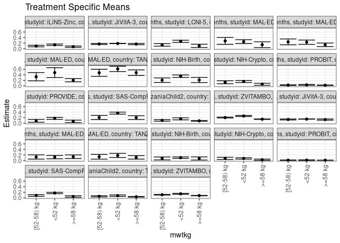

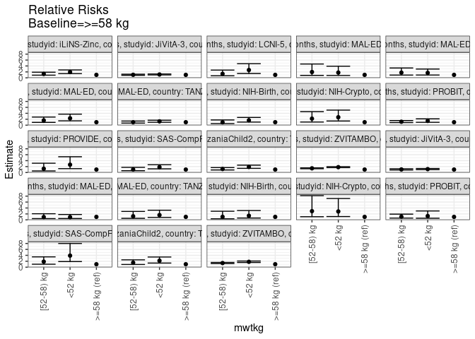

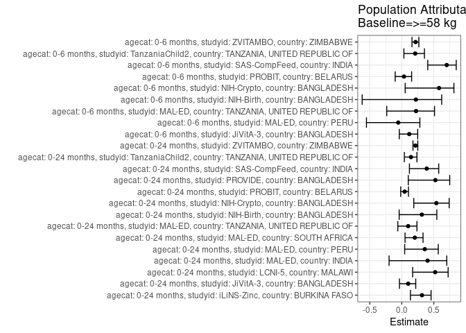

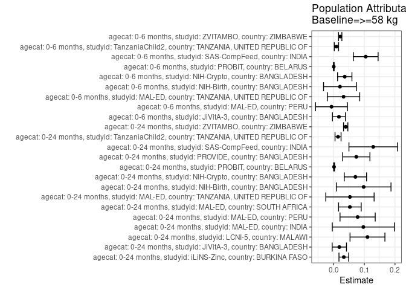

## Results Table

### Parameter: TSM

| agecat | studyid | country | intervention_level | baseline_level | estimate | ci_lower | ci_upper |
| --- | --- | --- | --- | --- | --- | --- | --- |
| 0-24 months | iLiNS-Zinc | BURKINA FASO | >=58 kg | NA | 0.0719358 | 0.0473379 | 0.0965336 |
| 0-24 months | iLiNS-Zinc | BURKINA FASO | <52 kg | NA | 0.1400046 | 0.1143664 | 0.1656427 |
| 0-24 months | iLiNS-Zinc | BURKINA FASO | [52-58) kg | NA | 0.0940839 | 0.0655968 | 0.1225711 |
| 0-24 months | JiVitA-3 | BANGLADESH | >=58 kg | NA | 0.1659893 | 0.1420538 | 0.1899247 |
| 0-24 months | JiVitA-3 | BANGLADESH | <52 kg | NA | 0.1863643 | 0.1805538 | 0.1921748 |
| 0-24 months | JiVitA-3 | BANGLADESH | [52-58) kg | NA | 0.1696590 | 0.1510677 | 0.1882504 |
| 0-24 months | LCNI-5 | MALAWI | >=58 kg | NA | 0.1009868 | 0.0430651 | 0.1589085 |
| 0-24 months | LCNI-5 | MALAWI | <52 kg | NA | 0.2663969 | 0.2277262 | 0.3050676 |
| 0-24 months | LCNI-5 | MALAWI | [52-58) kg | NA | 0.1351173 | 0.0887182 | 0.1815163 |
| 0-24 months | MAL-ED | INDIA | >=58 kg | NA | 0.1428571 | 0.0368097 | 0.2489046 |
| 0-24 months | MAL-ED | INDIA | <52 kg | NA | 0.2533333 | 0.1835886 | 0.3230780 |
| 0-24 months | MAL-ED | INDIA | [52-58) kg | NA | 0.2800000 | 0.1552882 | 0.4047118 |
| 0-24 months | MAL-ED | PERU | >=58 kg | NA | 0.1391187 | 0.0745904 | 0.2036471 |
| 0-24 months | MAL-ED | PERU | <52 kg | NA | 0.2330448 | 0.1548687 | 0.3112208 |
| 0-24 months | MAL-ED | PERU | [52-58) kg | NA | 0.2447263 | 0.1396306 | 0.3498220 |
| 0-24 months | MAL-ED | SOUTH AFRICA | >=58 kg | NA | 0.2063319 | 0.1488374 | 0.2638264 |
| 0-24 months | MAL-ED | SOUTH AFRICA | <52 kg | NA | 0.4802864 | 0.3014055 | 0.6591673 |
| 0-24 months | MAL-ED | SOUTH AFRICA | [52-58) kg | NA | 0.3319740 | 0.1831549 | 0.4807931 |
| 0-24 months | MAL-ED | TANZANIA, UNITED REPUBLIC OF | >=58 kg | NA | 0.4781009 | 0.3778929 | 0.5783090 |
| 0-24 months | MAL-ED | TANZANIA, UNITED REPUBLIC OF | <52 kg | NA | 0.6137155 | 0.5170990 | 0.7103320 |
| 0-24 months | MAL-ED | TANZANIA, UNITED REPUBLIC OF | [52-58) kg | NA | 0.4749106 | 0.3464940 | 0.6033272 |
| 0-24 months | NIH-Birth | BANGLADESH | >=58 kg | NA | 0.2138056 | 0.1199480 | 0.3076631 |
| 0-24 months | NIH-Birth | BANGLADESH | <52 kg | NA | 0.3521023 | 0.3079451 | 0.3962594 |
| 0-24 months | NIH-Birth | BANGLADESH | [52-58) kg | NA | 0.2077677 | 0.1260768 | 0.2894586 |
| 0-24 months | NIH-Crypto | BANGLADESH | >=58 kg | NA | 0.0601964 | 0.0238109 | 0.0965819 |
| 0-24 months | NIH-Crypto | BANGLADESH | <52 kg | NA | 0.1609596 | 0.1253446 | 0.1965746 |
| 0-24 months | NIH-Crypto | BANGLADESH | [52-58) kg | NA | 0.1327028 | 0.0788827 | 0.1865229 |
| 0-24 months | PROBIT | BELARUS | >=58 kg | NA | 0.0260513 | 0.0186058 | 0.0334968 |
| 0-24 months | PROBIT | BELARUS | <52 kg | NA | 0.0375646 | 0.0223215 | 0.0528076 |
| 0-24 months | PROBIT | BELARUS | [52-58) kg | NA | 0.0302972 | 0.0194441 | 0.0411503 |
| 0-24 months | PROVIDE | BANGLADESH | >=58 kg | NA | 0.0666667 | 0.0220029 | 0.1113304 |
| 0-24 months | PROVIDE | BANGLADESH | <52 kg | NA | 0.1759259 | 0.1399941 | 0.2118577 |
| 0-24 months | PROVIDE | BANGLADESH | [52-58) kg | NA | 0.0854701 | 0.0347726 | 0.1361675 |
| 0-24 months | SAS-CompFeed | INDIA | >=58 kg | NA | 0.2016896 | 0.1326257 | 0.2707535 |
| 0-24 months | SAS-CompFeed | INDIA | <52 kg | NA | 0.3636297 | 0.3271629 | 0.4000964 |
| 0-24 months | SAS-CompFeed | INDIA | [52-58) kg | NA | 0.2061081 | 0.1311438 | 0.2810724 |
| 0-24 months | TanzaniaChild2 | TANZANIA, UNITED REPUBLIC OF | >=58 kg | NA | 0.0847729 | 0.0704805 | 0.0990653 |
| 0-24 months | TanzaniaChild2 | TANZANIA, UNITED REPUBLIC OF | <52 kg | NA | 0.1584996 | 0.1215825 | 0.1954168 |
| 0-24 months | TanzaniaChild2 | TANZANIA, UNITED REPUBLIC OF | [52-58) kg | NA | 0.1009752 | 0.0725299 | 0.1294204 |
| 0-24 months | ZVITAMBO | ZIMBABWE | >=58 kg | NA | 0.1443559 | 0.1352635 | 0.1534483 |
| 0-24 months | ZVITAMBO | ZIMBABWE | <52 kg | NA | 0.2604986 | 0.2425662 | 0.2784310 |
| 0-24 months | ZVITAMBO | ZIMBABWE | [52-58) kg | NA | 0.2037763 | 0.1888384 | 0.2187143 |
| 0-6 months | JiVitA-3 | BANGLADESH | >=58 kg | NA | 0.1301444 | 0.1084360 | 0.1518528 |
| 0-6 months | JiVitA-3 | BANGLADESH | <52 kg | NA | 0.1487149 | 0.1434986 | 0.1539313 |
| 0-6 months | JiVitA-3 | BANGLADESH | [52-58) kg | NA | 0.1352398 | 0.1186227 | 0.1518569 |
| 0-6 months | MAL-ED | PERU | >=58 kg | NA | 0.1346154 | 0.0689051 | 0.2003257 |
| 0-6 months | MAL-ED | PERU | <52 kg | NA | 0.1217391 | 0.0618737 | 0.1816046 |
| 0-6 months | MAL-ED | PERU | [52-58) kg | NA | 0.1267606 | 0.0492381 | 0.2042831 |
| 0-6 months | MAL-ED | TANZANIA, UNITED REPUBLIC OF | >=58 kg | NA | 0.1122449 | 0.0496246 | 0.1748652 |
| 0-6 months | MAL-ED | TANZANIA, UNITED REPUBLIC OF | <52 kg | NA | 0.1818182 | 0.1056938 | 0.2579426 |
| 0-6 months | MAL-ED | TANZANIA, UNITED REPUBLIC OF | [52-58) kg | NA | 0.1355932 | 0.0480646 | 0.2231218 |
| 0-6 months | NIH-Birth | BANGLADESH | >=58 kg | NA | 0.0731707 | 0.0167608 | 0.1295806 |
| 0-6 months | NIH-Birth | BANGLADESH | <52 kg | NA | 0.1015453 | 0.0737083 | 0.1293823 |
| 0-6 months | NIH-Birth | BANGLADESH | [52-58) kg | NA | 0.0744681 | 0.0213539 | 0.1275823 |
| 0-6 months | NIH-Crypto | BANGLADESH | >=58 kg | NA | 0.0260417 | 0.0034998 | 0.0485835 |
| 0-6 months | NIH-Crypto | BANGLADESH | <52 kg | NA | 0.0738916 | 0.0484291 | 0.0993541 |
| 0-6 months | NIH-Crypto | BANGLADESH | [52-58) kg | NA | 0.0764331 | 0.0348458 | 0.1180205 |
| 0-6 months | PROBIT | BELARUS | >=58 kg | NA | 0.0094679 | 0.0061651 | 0.0127707 |
| 0-6 months | PROBIT | BELARUS | <52 kg | NA | 0.0121334 | 0.0019736 | 0.0222932 |
| 0-6 months | PROBIT | BELARUS | [52-58) kg | NA | 0.0101028 | 0.0032164 | 0.0169891 |
| 0-6 months | SAS-CompFeed | INDIA | >=58 kg | NA | 0.0442478 | 0.0170549 | 0.0714407 |
| 0-6 months | SAS-CompFeed | INDIA | <52 kg | NA | 0.1727116 | 0.1479652 | 0.1974580 |
| 0-6 months | SAS-CompFeed | INDIA | [52-58) kg | NA | 0.0829876 | 0.0537728 | 0.1122023 |
| 0-6 months | TanzaniaChild2 | TANZANIA, UNITED REPUBLIC OF | >=58 kg | NA | 0.0339284 | 0.0244780 | 0.0433787 |
| 0-6 months | TanzaniaChild2 | TANZANIA, UNITED REPUBLIC OF | <52 kg | NA | 0.0742425 | 0.0478932 | 0.1005918 |
| 0-6 months | TanzaniaChild2 | TANZANIA, UNITED REPUBLIC OF | [52-58) kg | NA | 0.0515556 | 0.0306515 | 0.0724597 |
| 0-6 months | ZVITAMBO | ZIMBABWE | >=58 kg | NA | 0.0778445 | 0.0709067 | 0.0847822 |
| 0-6 months | ZVITAMBO | ZIMBABWE | <52 kg | NA | 0.1418053 | 0.1274568 | 0.1561537 |
| 0-6 months | ZVITAMBO | ZIMBABWE | [52-58) kg | NA | 0.1086333 | 0.0970408 | 0.1202258 |

### Parameter: E(Y)

| agecat | studyid | country | intervention_level | baseline_level | estimate | ci_lower | ci_upper |
| --- | --- | --- | --- | --- | --- | --- | --- |
| 0-24 months | iLiNS-Zinc | BURKINA FASO | NA | NA | 0.1050995 | 0.0855497 | 0.1246493 |
| 0-24 months | JiVitA-3 | BANGLADESH | NA | NA | 0.1844757 | 0.1788759 | 0.1900754 |
| 0-24 months | LCNI-5 | MALAWI | NA | NA | 0.2112172 | 0.1835650 | 0.2388693 |
| 0-24 months | MAL-ED | INDIA | NA | NA | 0.2396694 | 0.1857746 | 0.2935643 |
| 0-24 months | MAL-ED | PERU | NA | NA | 0.2172414 | 0.1696986 | 0.2647841 |
| 0-24 months | MAL-ED | SOUTH AFRICA | NA | NA | 0.2592593 | 0.2068905 | 0.3116280 |
| 0-24 months | MAL-ED | TANZANIA, UNITED REPUBLIC OF | NA | NA | 0.5312500 | 0.4700011 | 0.5924989 |
| 0-24 months | NIH-Birth | BANGLADESH | NA | NA | 0.3116057 | 0.2753823 | 0.3478292 |
| 0-24 months | NIH-Crypto | BANGLADESH | NA | NA | 0.1311258 | 0.1070332 | 0.1552185 |
| 0-24 months | PROBIT | BELARUS | NA | NA | 0.0273018 | 0.0201306 | 0.0344729 |
| 0-24 months | PROVIDE | BANGLADESH | NA | NA | 0.1405082 | 0.1141551 | 0.1668613 |
| 0-24 months | SAS-CompFeed | INDIA | NA | NA | 0.3306931 | 0.3017014 | 0.3596847 |
| 0-24 months | TanzaniaChild2 | TANZANIA, UNITED REPUBLIC OF | NA | NA | 0.0990646 | 0.0869885 | 0.1111408 |
| 0-24 months | ZVITAMBO | ZIMBABWE | NA | NA | 0.1835951 | 0.1764261 | 0.1907642 |
| 0-6 months | JiVitA-3 | BANGLADESH | NA | NA | 0.1473645 | 0.1423155 | 0.1524136 |
| 0-6 months | MAL-ED | PERU | NA | NA | 0.1275862 | 0.0891215 | 0.1660509 |
| 0-6 months | MAL-ED | TANZANIA, UNITED REPUBLIC OF | NA | NA | 0.1445312 | 0.1013733 | 0.1876892 |
| 0-6 months | NIH-Birth | BANGLADESH | NA | NA | 0.0937997 | 0.0709973 | 0.1166021 |
| 0-6 months | NIH-Crypto | BANGLADESH | NA | NA | 0.0622517 | 0.0450059 | 0.0794974 |
| 0-6 months | PROBIT | BELARUS | NA | NA | 0.0098025 | 0.0063729 | 0.0132321 |
| 0-6 months | SAS-CompFeed | INDIA | NA | NA | 0.1488095 | 0.1307571 | 0.1668620 |
| 0-6 months | TanzaniaChild2 | TANZANIA, UNITED REPUBLIC OF | NA | NA | 0.0429422 | 0.0347475 | 0.0511369 |
| 0-6 months | ZVITAMBO | ZIMBABWE | NA | NA | 0.0991957 | 0.0936569 | 0.1047345 |

### Parameter: RR

| agecat | studyid | country | intervention_level | baseline_level | estimate | ci_lower | ci_upper |
| --- | --- | --- | --- | --- | --- | --- | --- |
| 0-24 months | iLiNS-Zinc | BURKINA FASO | >=58 kg | >=58 kg | 1.0000000 | 1.0000000 | 1.000000 |
| 0-24 months | iLiNS-Zinc | BURKINA FASO | <52 kg | >=58 kg | 1.9462442 | 1.4211428 | 2.665366 |
| 0-24 months | iLiNS-Zinc | BURKINA FASO | [52-58) kg | >=58 kg | 1.3078880 | 0.9005506 | 1.899472 |
| 0-24 months | JiVitA-3 | BANGLADESH | >=58 kg | >=58 kg | 1.0000000 | 1.0000000 | 1.000000 |
| 0-24 months | JiVitA-3 | BANGLADESH | <52 kg | >=58 kg | 1.1227491 | 0.9721137 | 1.296726 |
| 0-24 months | JiVitA-3 | BANGLADESH | [52-58) kg | >=58 kg | 1.0221085 | 0.8528821 | 1.224913 |
| 0-24 months | LCNI-5 | MALAWI | >=58 kg | >=58 kg | 1.0000000 | 1.0000000 | 1.000000 |
| 0-24 months | LCNI-5 | MALAWI | <52 kg | >=58 kg | 2.6379381 | 1.4593368 | 4.768410 |
| 0-24 months | LCNI-5 | MALAWI | [52-58) kg | >=58 kg | 1.3379697 | 0.6858149 | 2.610271 |
| 0-24 months | MAL-ED | INDIA | >=58 kg | >=58 kg | 1.0000000 | 1.0000000 | 1.000000 |
| 0-24 months | MAL-ED | INDIA | <52 kg | >=58 kg | 1.7733333 | 0.8034193 | 3.914159 |
| 0-24 months | MAL-ED | INDIA | [52-58) kg | >=58 kg | 1.9600000 | 0.8246831 | 4.658274 |
| 0-24 months | MAL-ED | PERU | >=58 kg | >=58 kg | 1.0000000 | 1.0000000 | 1.000000 |
| 0-24 months | MAL-ED | PERU | <52 kg | >=58 kg | 1.6751502 | 0.9440312 | 2.972495 |
| 0-24 months | MAL-ED | PERU | [52-58) kg | >=58 kg | 1.7591185 | 0.9327916 | 3.317459 |
| 0-24 months | MAL-ED | SOUTH AFRICA | >=58 kg | >=58 kg | 1.0000000 | 1.0000000 | 1.000000 |
| 0-24 months | MAL-ED | SOUTH AFRICA | <52 kg | >=58 kg | 2.3277370 | 1.4600049 | 3.711193 |
| 0-24 months | MAL-ED | SOUTH AFRICA | [52-58) kg | >=58 kg | 1.6089319 | 0.9467438 | 2.734279 |
| 0-24 months | MAL-ED | TANZANIA, UNITED REPUBLIC OF | >=58 kg | >=58 kg | 1.0000000 | 1.0000000 | 1.000000 |
| 0-24 months | MAL-ED | TANZANIA, UNITED REPUBLIC OF | <52 kg | >=58 kg | 1.2836526 | 0.9874295 | 1.668741 |
| 0-24 months | MAL-ED | TANZANIA, UNITED REPUBLIC OF | [52-58) kg | >=58 kg | 0.9933271 | 0.7053254 | 1.398927 |
| 0-24 months | NIH-Birth | BANGLADESH | >=58 kg | >=58 kg | 1.0000000 | 1.0000000 | 1.000000 |
| 0-24 months | NIH-Birth | BANGLADESH | <52 kg | >=58 kg | 1.6468341 | 1.0427210 | 2.600947 |
| 0-24 months | NIH-Birth | BANGLADESH | [52-58) kg | >=58 kg | 0.9717600 | 0.5390297 | 1.751884 |
| 0-24 months | NIH-Crypto | BANGLADESH | >=58 kg | >=58 kg | 1.0000000 | 1.0000000 | 1.000000 |
| 0-24 months | NIH-Crypto | BANGLADESH | <52 kg | >=58 kg | 2.6739090 | 1.4062733 | 5.084210 |
| 0-24 months | NIH-Crypto | BANGLADESH | [52-58) kg | >=58 kg | 2.2044986 | 1.0641170 | 4.566992 |
| 0-24 months | PROBIT | BELARUS | >=58 kg | >=58 kg | 1.0000000 | 1.0000000 | 1.000000 |
| 0-24 months | PROBIT | BELARUS | <52 kg | >=58 kg | 1.4419484 | 0.9729252 | 2.137076 |
| 0-24 months | PROBIT | BELARUS | [52-58) kg | >=58 kg | 1.1629852 | 0.8742659 | 1.547052 |
| 0-24 months | PROVIDE | BANGLADESH | >=58 kg | >=58 kg | 1.0000000 | 1.0000000 | 1.000000 |
| 0-24 months | PROVIDE | BANGLADESH | <52 kg | >=58 kg | 2.6388889 | 1.3099126 | 5.316183 |
| 0-24 months | PROVIDE | BANGLADESH | [52-58) kg | >=58 kg | 1.2820513 | 0.5239569 | 3.137005 |
| 0-24 months | SAS-CompFeed | INDIA | >=58 kg | >=58 kg | 1.0000000 | 1.0000000 | 1.000000 |
| 0-24 months | SAS-CompFeed | INDIA | <52 kg | >=58 kg | 1.8029177 | 1.2366372 | 2.628509 |
| 0-24 months | SAS-CompFeed | INDIA | [52-58) kg | >=58 kg | 1.0219077 | 0.6001578 | 1.740035 |
| 0-24 months | TanzaniaChild2 | TANZANIA, UNITED REPUBLIC OF | >=58 kg | >=58 kg | 1.0000000 | 1.0000000 | 1.000000 |
| 0-24 months | TanzaniaChild2 | TANZANIA, UNITED REPUBLIC OF | <52 kg | >=58 kg | 1.8696974 | 1.4022173 | 2.493029 |
| 0-24 months | TanzaniaChild2 | TANZANIA, UNITED REPUBLIC OF | [52-58) kg | >=58 kg | 1.1911258 | 0.8576600 | 1.654246 |
| 0-24 months | ZVITAMBO | ZIMBABWE | >=58 kg | >=58 kg | 1.0000000 | 1.0000000 | 1.000000 |
| 0-24 months | ZVITAMBO | ZIMBABWE | <52 kg | >=58 kg | 1.8045583 | 1.6439178 | 1.980896 |
| 0-24 months | ZVITAMBO | ZIMBABWE | [52-58) kg | >=58 kg | 1.4116246 | 1.2817204 | 1.554695 |
| 0-6 months | JiVitA-3 | BANGLADESH | >=58 kg | >=58 kg | 1.0000000 | 1.0000000 | 1.000000 |
| 0-6 months | JiVitA-3 | BANGLADESH | <52 kg | >=58 kg | 1.1426915 | 0.9673410 | 1.349828 |
| 0-6 months | JiVitA-3 | BANGLADESH | [52-58) kg | >=58 kg | 1.0391518 | 0.8481491 | 1.273168 |
| 0-6 months | MAL-ED | PERU | >=58 kg | >=58 kg | 1.0000000 | 1.0000000 | 1.000000 |
| 0-6 months | MAL-ED | PERU | <52 kg | >=58 kg | 0.9043478 | 0.4522910 | 1.808228 |
| 0-6 months | MAL-ED | PERU | [52-58) kg | >=58 kg | 0.9416499 | 0.4305852 | 2.059301 |
| 0-6 months | MAL-ED | TANZANIA, UNITED REPUBLIC OF | >=58 kg | >=58 kg | 1.0000000 | 1.0000000 | 1.000000 |
| 0-6 months | MAL-ED | TANZANIA, UNITED REPUBLIC OF | <52 kg | >=58 kg | 1.6198347 | 0.8063817 | 3.253874 |
| 0-6 months | MAL-ED | TANZANIA, UNITED REPUBLIC OF | [52-58) kg | >=58 kg | 1.2080123 | 0.5146756 | 2.835366 |
| 0-6 months | NIH-Birth | BANGLADESH | >=58 kg | >=58 kg | 1.0000000 | 1.0000000 | 1.000000 |
| 0-6 months | NIH-Birth | BANGLADESH | <52 kg | >=58 kg | 1.3877851 | 0.6123111 | 3.145374 |
| 0-6 months | NIH-Birth | BANGLADESH | [52-58) kg | >=58 kg | 1.0177305 | 0.3560469 | 2.909098 |
| 0-6 months | NIH-Crypto | BANGLADESH | >=58 kg | >=58 kg | 1.0000000 | 1.0000000 | 1.000000 |
| 0-6 months | NIH-Crypto | BANGLADESH | <52 kg | >=58 kg | 2.8374384 | 1.1176468 | 7.203579 |
| 0-6 months | NIH-Crypto | BANGLADESH | [52-58) kg | >=58 kg | 2.9350318 | 1.0558100 | 8.159055 |
| 0-6 months | PROBIT | BELARUS | >=58 kg | >=58 kg | 1.0000000 | 1.0000000 | 1.000000 |
| 0-6 months | PROBIT | BELARUS | <52 kg | >=58 kg | 1.2815311 | 0.5476834 | 2.998671 |
| 0-6 months | PROBIT | BELARUS | [52-58) kg | >=58 kg | 1.0670525 | 0.5904805 | 1.928262 |
| 0-6 months | SAS-CompFeed | INDIA | >=58 kg | >=58 kg | 1.0000000 | 1.0000000 | 1.000000 |
| 0-6 months | SAS-CompFeed | INDIA | <52 kg | >=58 kg | 3.9032815 | 1.9049723 | 7.997810 |
| 0-6 months | SAS-CompFeed | INDIA | [52-58) kg | >=58 kg | 1.8755187 | 1.0096478 | 3.483958 |
| 0-6 months | TanzaniaChild2 | TANZANIA, UNITED REPUBLIC OF | >=58 kg | >=58 kg | 1.0000000 | 1.0000000 | 1.000000 |
| 0-6 months | TanzaniaChild2 | TANZANIA, UNITED REPUBLIC OF | <52 kg | >=58 kg | 2.1882142 | 1.3931718 | 3.436964 |
| 0-6 months | TanzaniaChild2 | TANZANIA, UNITED REPUBLIC OF | [52-58) kg | >=58 kg | 1.5195435 | 0.9288116 | 2.485986 |
| 0-6 months | ZVITAMBO | ZIMBABWE | >=58 kg | >=58 kg | 1.0000000 | 1.0000000 | 1.000000 |
| 0-6 months | ZVITAMBO | ZIMBABWE | <52 kg | >=58 kg | 1.8216483 | 1.5919987 | 2.084426 |
| 0-6 months | ZVITAMBO | ZIMBABWE | [52-58) kg | >=58 kg | 1.3955177 | 1.2144743 | 1.603549 |

### Parameter: PAR

| agecat | studyid | country | intervention_level | baseline_level | estimate | ci_lower | ci_upper |
| --- | --- | --- | --- | --- | --- | --- | --- |
| 0-24 months | iLiNS-Zinc | BURKINA FASO | >=58 kg | NA | 0.0331637 | 0.0173024 | 0.0490251 |
| 0-24 months | JiVitA-3 | BANGLADESH | >=58 kg | NA | 0.0184864 | -0.0048475 | 0.0418203 |
| 0-24 months | LCNI-5 | MALAWI | >=58 kg | NA | 0.1102304 | 0.0533609 | 0.1670999 |
| 0-24 months | MAL-ED | INDIA | >=58 kg | NA | 0.0968123 | -0.0044158 | 0.1980403 |
| 0-24 months | MAL-ED | PERU | >=58 kg | NA | 0.0781227 | 0.0207408 | 0.1355045 |
| 0-24 months | MAL-ED | SOUTH AFRICA | >=58 kg | NA | 0.0529273 | 0.0160353 | 0.0898194 |
| 0-24 months | MAL-ED | TANZANIA, UNITED REPUBLIC OF | >=58 kg | NA | 0.0531491 | -0.0256121 | 0.1319102 |
| 0-24 months | NIH-Birth | BANGLADESH | >=58 kg | NA | 0.0978002 | 0.0086447 | 0.1869556 |
| 0-24 months | NIH-Crypto | BANGLADESH | >=58 kg | NA | 0.0709295 | 0.0345199 | 0.1073391 |
| 0-24 months | PROBIT | BELARUS | >=58 kg | NA | 0.0012505 | -0.0003492 | 0.0028502 |
| 0-24 months | PROVIDE | BANGLADESH | >=58 kg | NA | 0.0738416 | 0.0294153 | 0.1182678 |
| 0-24 months | SAS-CompFeed | INDIA | >=58 kg | NA | 0.1290035 | 0.0498653 | 0.2081417 |
| 0-24 months | TanzaniaChild2 | TANZANIA, UNITED REPUBLIC OF | >=58 kg | NA | 0.0142917 | 0.0044546 | 0.0241289 |
| 0-24 months | ZVITAMBO | ZIMBABWE | >=58 kg | NA | 0.0392392 | 0.0322209 | 0.0462576 |
| 0-6 months | JiVitA-3 | BANGLADESH | >=58 kg | NA | 0.0172201 | -0.0039025 | 0.0383427 |
| 0-6 months | MAL-ED | PERU | >=58 kg | NA | -0.0070292 | -0.0589949 | 0.0449366 |
| 0-6 months | MAL-ED | TANZANIA, UNITED REPUBLIC OF | >=58 kg | NA | 0.0322864 | -0.0204551 | 0.0850278 |
| 0-6 months | NIH-Birth | BANGLADESH | >=58 kg | NA | 0.0206290 | -0.0329654 | 0.0742233 |
| 0-6 months | NIH-Crypto | BANGLADESH | >=58 kg | NA | 0.0362100 | 0.0128197 | 0.0596003 |
| 0-6 months | PROBIT | BELARUS | >=58 kg | NA | 0.0003346 | -0.0009497 | 0.0016189 |
| 0-6 months | SAS-CompFeed | INDIA | >=58 kg | NA | 0.1045617 | 0.0641514 | 0.1449721 |
| 0-6 months | TanzaniaChild2 | TANZANIA, UNITED REPUBLIC OF | >=58 kg | NA | 0.0090138 | 0.0019626 | 0.0160651 |
| 0-6 months | ZVITAMBO | ZIMBABWE | >=58 kg | NA | 0.0213512 | 0.0159225 | 0.0267800 |

### Parameter: PAF

| agecat | studyid | country | intervention_level | baseline_level | estimate | ci_lower | ci_upper |
| --- | --- | --- | --- | --- | --- | --- | --- |
| 0-24 months | iLiNS-Zinc | BURKINA FASO | >=58 kg | NA | 0.3155461 | 0.1360864 | 0.4577269 |
| 0-24 months | JiVitA-3 | BANGLADESH | >=58 kg | NA | 0.1002105 | -0.0356023 | 0.2182123 |
| 0-24 months | LCNI-5 | MALAWI | >=58 kg | NA | 0.5218818 | 0.1697217 | 0.7246743 |
| 0-24 months | MAL-ED | INDIA | >=58 kg | NA | 0.4039409 | -0.1982678 | 0.7034999 |
| 0-24 months | MAL-ED | PERU | >=58 kg | NA | 0.3596122 | 0.0453448 | 0.5704245 |
| 0-24 months | MAL-ED | SOUTH AFRICA | >=58 kg | NA | 0.2041483 | 0.0513958 | 0.3323033 |
| 0-24 months | MAL-ED | TANZANIA, UNITED REPUBLIC OF | >=58 kg | NA | 0.1000453 | -0.0617724 | 0.2372014 |
| 0-24 months | NIH-Birth | BANGLADESH | >=58 kg | NA | 0.3138587 | -0.0408044 | 0.5476673 |
| 0-24 months | NIH-Crypto | BANGLADESH | >=58 kg | NA | 0.5409267 | 0.1875954 | 0.7405870 |
| 0-24 months | PROBIT | BELARUS | >=58 kg | NA | 0.0458032 | -0.0167172 | 0.1044790 |
| 0-24 months | PROVIDE | BANGLADESH | >=58 kg | NA | 0.5255319 | 0.1015731 | 0.7494287 |
| 0-24 months | SAS-CompFeed | INDIA | >=58 kg | NA | 0.3901004 | 0.1196287 | 0.5774766 |
| 0-24 months | TanzaniaChild2 | TANZANIA, UNITED REPUBLIC OF | >=58 kg | NA | 0.1442668 | 0.0404214 | 0.2368742 |
| 0-24 months | ZVITAMBO | ZIMBABWE | >=58 kg | NA | 0.2137271 | 0.1751691 | 0.2504826 |
| 0-6 months | JiVitA-3 | BANGLADESH | >=58 kg | NA | 0.1168540 | -0.0388261 | 0.2492036 |
| 0-6 months | MAL-ED | PERU | >=58 kg | NA | -0.0550936 | -0.5518361 | 0.2826418 |
| 0-6 months | MAL-ED | TANZANIA, UNITED REPUBLIC OF | >=58 kg | NA | 0.2233867 | -0.2352083 | 0.5117193 |
| 0-6 months | NIH-Birth | BANGLADESH | >=58 kg | NA | 0.2199256 | -0.6183339 | 0.6239861 |
| 0-6 months | NIH-Crypto | BANGLADESH | >=58 kg | NA | 0.5816711 | 0.0535431 | 0.8151009 |
| 0-6 months | PROBIT | BELARUS | >=58 kg | NA | 0.0341336 | -0.1028948 | 0.1541369 |
| 0-6 months | SAS-CompFeed | INDIA | >=58 kg | NA | 0.7026549 | 0.4061002 | 0.8511295 |
| 0-6 months | TanzaniaChild2 | TANZANIA, UNITED REPUBLIC OF | >=58 kg | NA | 0.2099060 | 0.0332061 | 0.3543106 |
| 0-6 months | ZVITAMBO | ZIMBABWE | >=58 kg | NA | 0.2152436 | 0.1597333 | 0.2670867 |